# Technology and Social Change

Lecture 11: Technology, Labor & Automation

Bogdan G. Popescu

bgpopescu@tec.mx

Tecnológico de Monterrey

## Three Motivating Puzzles

**Puzzle 1 — Two Centuries of Automation, More Jobs Than Ever**

If new technology kills jobs, why does total employment keep rising?

**Puzzle 2 — The Disappearing Middle**

Why are middle-skill jobs hollowing out while *both* the top and the bottom grow?

**Puzzle 3 — Same Machines, Different Societies**

Why does the same technology produce sharp inequality in some countries and shared prosperity in others?

[figure not shown]

Automated warehouse robots at Ocado. Modern logistics automation exemplifies the “automation anxiety” puzzle. Photo: Techworld / Wikimedia Commons (CC BY-SA 4.0).

## Learning Objectives

By the end of this lecture, you should be able to:

1. Apply the **task-based framework** — three forces (displacement, productivity, reinstatement) — to historical and modern automation
2. Explain why scary headlines like *“47% of jobs at risk”* overstate the real impact
3. Distinguish four mechanisms linking technology to labor outcomes (SBTC, RBTC, geography, productivity–wage decoupling)
4. Show how **institutions mediate** the same technology into very different distributional outcomes
5. Compare policy levers — from cushioning displacement to reshaping the technology itself

# Conceptual Framework

## The “Simple” Automation Model

**The intuitive story** (the one behind most AI anxiety today):

> A machine does what a worker did → that worker loses the job → total employment falls.

Same logic the **Luddites** used in the 1810s when smashing power looms.

## Why It Breaks Down — Three Hidden Assumptions

- **Fixed amount of work (“lump of labor”).** *ATMs made branches cheaper → banks opened more of them → teller employment kept rising.*
- **Tech only destroys jobs, never creates them.** *“Software developer” and “data analyst” didn’t exist in 1900. Most jobs today were invented by past tech revolutions.*
- **Same tech, same outcome everywhere.** *Germany and the U.S. adopt robots at similar rates — yet inequality looks very different.*

**The key error:** confusing **task displacement** with **total job loss** (Acemoglu & Restrepo, 2019).

## The Task-Based Framework

**Key Insight**

Jobs are **bundles of tasks**. Technology affects tasks, not jobs directly.

```
┌────────────────────────────────────────────────────────┐
│                    JOB DECOMPOSITION                   │
│                                                        │
│    "Accountant" = { data entry, analysis, client       │
│                     communication, judgment calls }    │
│                                                        │
│    Automation affects these tasks differentially:      │
│    • Data entry: HIGH substitution potential           │
│    • Analysis: PARTIAL augmentation                    │
│    • Communication: LOW substitution potential         │
│    • Judgment: VERY LOW substitution potential         │
└────────────────────────────────────────────────────────┘
```

## Autor’s Task Taxonomy

| Task Type | Examples | Automation Risk |
| --- | --- | --- |
| **Routine Cognitive** | Data entry, bookkeeping | HIGH |
| **Routine Manual** | Assembly, machine operation | HIGH |
| **Non-Routine Analytical** | Research, programming | VARIABLE |
| **Non-Routine Interpersonal** | Teaching, negotiation | LOW |
| **Non-Routine Manual** | Janitorial, food service | LOW |

Source: Autor, Levy & Murnane (2003)

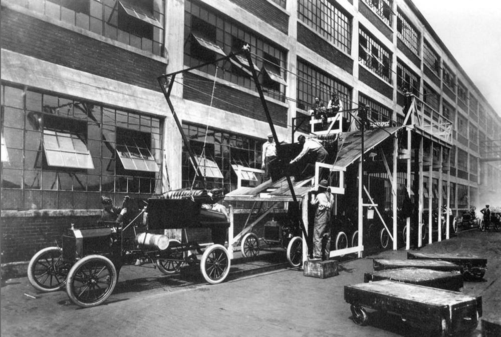

The Ford Model T assembly line (1913): routine manual tasks broken into repetitive steps — the classic target of automation. Source: Wikimedia Commons (public domain).

## The Acemoglu–Restrepo Framework

Technology hits labor through **three forces pulling in opposite directions:**

- **Displacement (−)** — machines take over tasks workers used to do. *A robot replaces a welder on the assembly line.*
- **Productivity (+)** — automation lowers costs → output expands → more demand for labor in the tasks machines *don’t* do. *Cheaper cars → more jobs in design, sales, and repair.*
- **Reinstatement (+)** — new tasks emerge where humans still hold the advantage. *MRI technicians, software developers, AI trainers — jobs that didn’t exist before the technology.*

**Net effect on jobs = (Productivity + Reinstatement) − Displacement**

Which side wins is **not predetermined** — it depends on policy, institutions, and the kinds of technology firms choose to build.

## Displacement-Reinstatement Model

```
%%{init: {'theme': 'base', 'themeVariables': {'fontSize': '20px', 'primaryColor': '#4a7c6f', 'primaryTextColor': '#1e293b', 'primaryBorderColor': '#334155', 'lineColor': '#64748b', 'secondaryColor': '#f9fafb', 'tertiaryColor': '#f9fafb'}, 'flowchart': {'useMaxWidth': true, 'nodeSpacing': 40, 'rankSp…
flowchart LR
    A["Technological<br/>Change"] --> B["Displacement<br/>Effect"]
    A --> C["Reinstatement<br/>Effect"]
    A --> D["Productivity<br/>Effect"]
    B --> E["Automates existing tasks<br/>(− Labor Demand)"]
    C --> F["Creates new tasks<br/>(+ Labor Demand)"]
    D --> G["Expands output<br/>(± Labor Demand)"]
    E --> H{"Net Employment<br/>Effect"}
    F --> H
    G --> H
    style A fill:#1e293b,color:#f9fafb,stroke:#334155
    style B fill:#b44527,color:#f9fafb,stroke:#334155
    style C fill:#4a7c6f,color:#f9fafb,stroke:#334155
    style D fill:#b7943a,color:#1e293b,stroke:#334155
    style H fill:#64748b,color:#f9fafb,stroke:#334155
```

Source: Based on Acemoglu & Restrepo (2019)

## Why Do Firms Over-Automate?

**Whether tech replaces or assists workers is a design choice** — not a property of the technology itself (Acemoglu, 2021).

So why do firms so often pick *replacement*?

- **Tax bias** — labor is heavily taxed (income, payroll, benefits)
- **Misaligned incentives** — automation looks profitable even when it isn’t socially efficient.
- **Result: “so-so automation”** — displaces workers without delivering productivity gains.

[figure not shown]

ATMs replaced cash-handling tasks but also made branches cheaper to run — banks opened more, and tellers shifted into customer service. Source: Wikimedia Commons.

# Four Mechanisms Linking Tech to Labor-Market Outcomes

## The Causal System

```
%%{init: {'theme': 'base', 'themeVariables': {'fontSize': '20px', 'primaryColor': '#4a7c6f', 'primaryTextColor': '#1e293b', 'primaryBorderColor': '#334155', 'lineColor': '#64748b', 'secondaryColor': '#f9fafb', 'tertiaryColor': '#f9fafb'}, 'flowchart': {'useMaxWidth': true, 'nodeSpacing': 50, 'rankSp…
flowchart LR
    A["Institutions<br/>(taxes, unions,<br/>education)"] -->|shape| B["Technological<br/>Change"]
    B --> C["Task<br/>Reconfiguration"]
    C --> D["Labor Market<br/>Adjustment"]
    D --> E["Distributional<br/>Outcomes"]
    E --> F["Political<br/>Responses<br/>(policy, parties)"]
    F -->|reshape| A

    style A fill:#4a7c6f,color:#f9fafb,stroke:#334155
    style B fill:#1e293b,color:#f9fafb,stroke:#334155
    style F fill:#b44527,color:#f9fafb,stroke:#334155
```

Causation is **recursive**: institutions shape technology and are reshaped by its consequences.

## What Each Mechanism Explains

These are **not competing theories.** They explain *different parts of the same labor-market transformation* — each answers a different observed pattern:

[output not shown]

## Mechanism 1: Skill-Biased Technological Change → *Rising College Premium*

**Definition**

**SBTC**: Technologies that raise the relative productivity and wages of skilled workers compared to unskilled workers.

**Causal pathway:** Computer tech → ↑ cognitive-skill demand → ↑ college premium → ↑ inequality

## U.S. College Wage Premium, 1963–2022

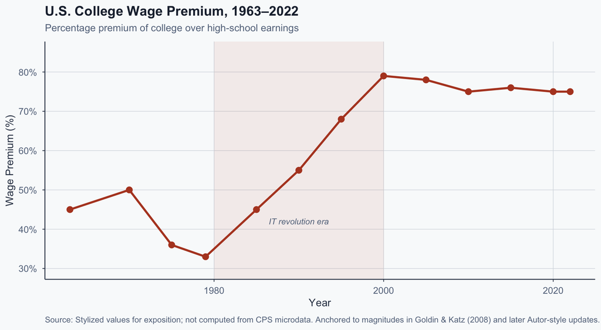

Figure 1: College vs. high-school earnings gap

## Mechanism 2: Routine-Biased Technological Change → *Job Polarization*

SBTC cannot explain **job polarization**. Autor (2003, 2013) proposes RBTC:

- **Computers only do what can be written as rules.** *If you can describe a task as a step-by-step checklist, software can replicate it.*
- **Routine tasks get automated — whether cognitive or manual.** *Bookkeeping → spreadsheets. Welding → robots.*
- **High-skill analytical work is complemented, not replaced.** *Software handles the routine parts, freeing engineers and doctors to focus on judgment.*
- **Low-skill in-person work survives because machines can’t (yet) do it.** *No robot reliably waits tables, cleans hotel rooms, or cares for the elderly.*
- **Middle-skill jobs — clerks, assemblers, machine operators — hollow out.** *Both ends grow; the middle disappears → “job polarization.”*

## U.S. Job Polarization, 1980–2005

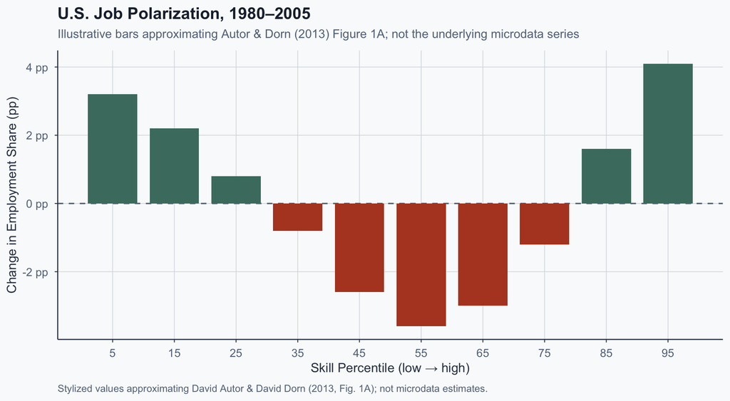

Figure 2: Employment share change by skill percentile

## Mechanism 3: Geographic Concentration → *Regional Decline*

Automation effects are **spatially concentrated**:

- Manufacturing automation devastated specific regions
- Knowledge economy concentrates in “superstar cities”
- Local labor markets adjust slowly — workers don’t move
- The China shock destroyed ~2.4 M U.S. jobs in specific commuting zones (Autor, Dorn & Hanson, 2013, 2016)

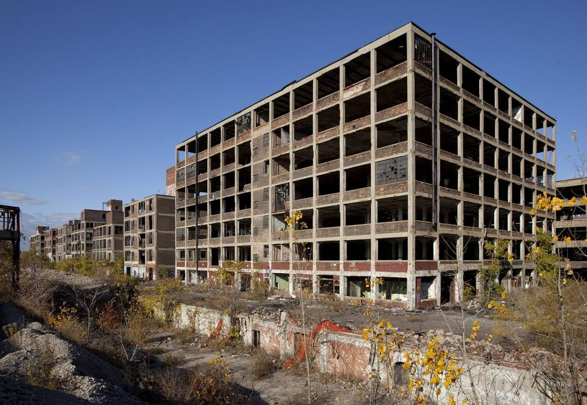

The abandoned Packard Automotive Plant, Detroit. Deindustrialization devastated specific regions while others thrived. Source: Wikimedia Commons (public domain).

## Mechanism 4: Productivity–Wage Decoupling → *Stagnant Pay*

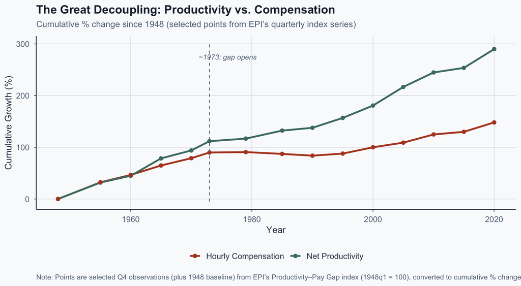

Figure 3: Productivity grew far faster than compensation

# Institutions & Path Dependence

## The Institutional Mediation Thesis

**Key Claim**

The *same technology* produces *different outcomes* across institutional contexts. Effects on employment, wages, and inequality are **institutionally contingent**.

## Same Technology, Different Outcomes

```
%%{init: {'theme': 'base', 'themeVariables': {'fontSize': '18px', 'primaryColor': '#4a7c6f', 'primaryTextColor': '#1e293b', 'primaryBorderColor': '#334155', 'lineColor': '#64748b', 'secondaryColor': '#f9fafb', 'tertiaryColor': '#f9fafb'}, 'flowchart': {'useMaxWidth': true, 'nodeSpacing': 30, 'rankSp…
flowchart TD
    A["Industrial Robots<br/>(Same Technology)"] --> B["Germany"]
    A --> C["United States"]
    A --> D["Sweden"]
    B --> E["Strong unions<br/>Vocational ed<br/>Codetermination"]
    C --> F["Weak unions<br/>Limited training<br/>Market-led"]
    D --> G["Strong unions<br/>Active labor<br/>market policy"]
    E --> H["Moderate inequality<br/>Job security"]
    F --> I["Sharp inequality<br/>Job loss"]
    G --> J["Low inequality<br/>Smooth transitions"]
    style A fill:#1e293b,color:#f9fafb,stroke:#334155
    style H fill:#b7943a,color:#1e293b,stroke:#334155
    style I fill:#b44527,color:#f9fafb,stroke:#334155
    style J fill:#4a7c6f,color:#f9fafb,stroke:#334155
```

Source: Conceptual diagram based on Hall & Soskice (2001); Thelen (2014)

## Path Dependence and Lock-In

**Brian Arthur’s Path Dependence**

Early institutional choices become self-reinforcing, making later changes difficult even when alternatives are superior.

**U.S. path:** Limited union institutionalization (1930s–50s) → weak safety net → few policy tools today

**Germany path:** Codetermination (1950s–70s) → strong works councils → technology adoption shaped by worker input

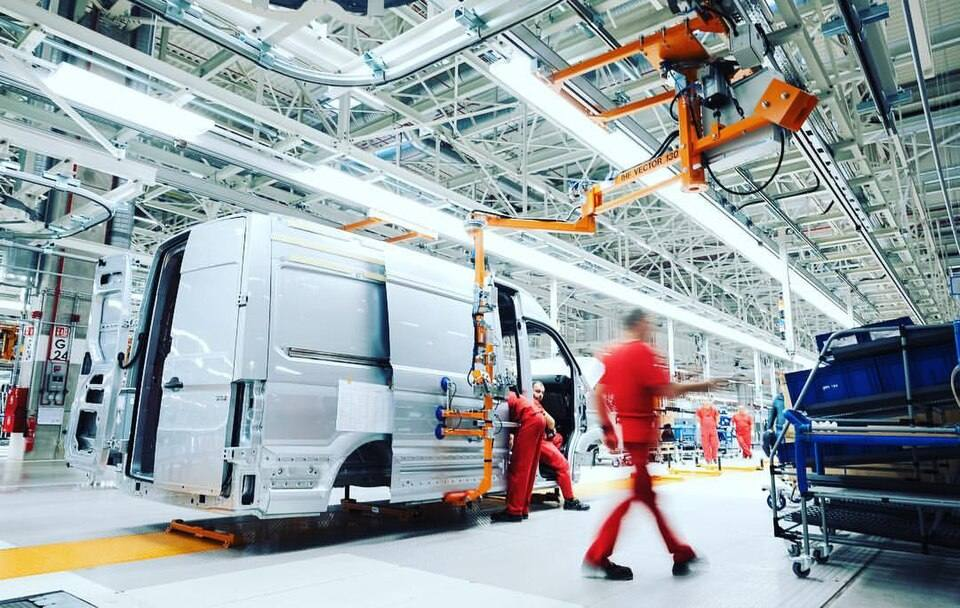

Workers on the VW Crafter assembly line, Wrzesnia. German codetermination gives workers voice in how automation is adopted. Photo: Karlis Dambrans (CC BY 2.0).

Source: Arthur (1989); Pierson (2004)

## Mokyr: Institutions Come *Before* Technology

*So far: institutions shape the **consequences** of technology. **Mokyr flips this** — institutions also shape **which technologies emerge in the first place**.*

- **Useful knowledge** spreads only when institutions let people share ideas openly.
- The **Industrial Enlightenment** — open science, patents, education — turned ideas into machines.
- Britain had this package; Song China and imperial Rome didn’t.
- **Today:** an AI revolution needs institutional innovation, not just better algorithms.

# Empirical Evidence

## The China Shock — A Window on How Labor-Market Shocks Actually Work

*The China shock isn’t strictly a technology shock — it’s a **trade shock**. But it teaches us how disruptive shocks to labor demand actually unfold: concentrated, persistent, politically explosive. The same dynamics apply to automation.*

**Autor, Dorn & Hanson (2013, 2016, 2021):**

[figure not shown]

Container ship NYK Themis at the Port of Los Angeles. The scale of global trade created concentrated regional shocks. Photo: Downtowngal / Wikimedia Commons (CC BY-SA 4.0).

## The China Shock — A Window on How Labor-Market Shocks Actually Work

- Import competition caused ~2.4 million U.S. job losses
- Effects concentrated in specific local labor markets
- Workers did not relocate; many left labor force
- Effects persisted for over a decade
- **Political consequence:** trade-exposed regions shifted toward populist candidates (Autor et al., 2020)

[figure not shown]

Container ship NYK Themis at the Port of Los Angeles. The scale of global trade created concentrated regional shocks. Photo: Downtowngal / Wikimedia Commons (CC BY-SA 4.0).

## Case Evidence: The China Shock in Three U.S. Regions

[video not shown]

Source: https://www.youtube.com/watch?v=SreJlZGd1c0

## Expert Voice: David Autor on the China Shock

[video not shown]

Source: https://www.youtube.com/watch?v=lUngEbyiaFs

1. What does Autor mean by **“pie vs. slice”** — and why does it matter?  
2. Tech or trade? How does Autor’s “1980 vs. 2000” split reshape the debate?  
3. Autor says we could have slowed it down — what policy tools were available?

## Frey & Osborne (2017): Automation Risk

**Headline finding:**

> “47% of U.S. employment at high risk of automation.”

**Why the 47% is misleading:**

- **They labeled whole jobs “automatable” — but every job is made of many different tasks.** *A nurse gives injections (maybe automatable) AND comforts scared patients (not). Replacing one task doesn’t replace the nurse.*
- **“A machine could do it” is not the same as “a company will replace the worker.”** *Robots are expensive, customers often prefer humans, and regulators are slow. Just because something is technically possible doesn’t mean it will happen.*

## Frey & Osborne (2017): Automation Risk

**Headline finding:**

> “47% of U.S. employment at high risk of automation.”

**Why the 47% is misleading:**

- **When researchers fixed the method, the scary number collapsed.** *The OECD redid the study task-by-task instead of job-by-job: only **9%** of jobs were at high risk — five times smaller than 47% (Arntz, Gregory & Zierahn, 2016).*

# How Should We Interpret the Evidence on Technology and Jobs?

## Two Camps: Determinism vs. Contingency

**What we’ve seen so far:**

- Automation displaced workers — welders on the line, middle-skill clerks, whole regions hit by the China shock.
- Yet Germany and the U.S. adopted similar technology and ended up with very different inequality.
- The scary “47% of jobs at risk” shrank to **9%** on closer analysis.

## Two Camps: Determinism vs. Contingency

**How should we read all of this?** Scholars split into two camps:

|  | **“It’s Inevitable”** *(Determinism)* | **“It Depends on Us”** *(Contingency)* |
| --- | --- | --- |
| **Who’s in charge?** | Technology pushes society wherever it goes. | People and institutions decide what tech does to us. |
| **Can we change the outcome?** | No — we just have to adapt. | Yes — through laws, schools, unions, taxes. |
| **Is AI a special case?** | Yes — *this time* really is different. | No — it’s one more transition we can manage. |
| **Who argues this?** | Tech leaders & futurists (Brynjolfsson, Kurzweil). | Economists & historians (Acemoglu, Autor, Mokyr). |

**The sharper formulation:** technology *creates pressures*; institutions *shape how the gains and losses are distributed*. The right question is not *“Will AI take our jobs?”* but **“What institutions will we build so that progress benefits broadly?”**

# Modern Relevance

## What Does AI Do to the Three Forces?

AI extends automation into **non-routine cognitive work** — tasks once thought safe. The same A–R three-force framework still applies:

- **Displacement (−):** ChatGPT writes first drafts, summaries, and customer-service replies → fewer hours for paralegals, copywriters, and junior analysts.
- **Productivity (+):** Doctors, lawyers, and engineers using AI tools deliver more work per hour → demand for their services can grow.
- **Reinstatement (+):** New roles emerge — prompt engineers, AI safety researchers, model evaluators.

**What’s actually new about AI** isn’t *whether* the framework applies — it’s the **speed** (months, not decades) and the **target** (cognitive jobs, not just manual ones).

## Platform Labor and the Gig Economy

**Platform Dynamics**

Digital platforms restructure employment relationships in ways that often shift risk to workers.

- Independent contractor status avoids labor protections
- Algorithmic management replaces human supervisors
- Task-level labor markets atomize work
- Surveillance and control without employment rights

**Examples:** Uber, DoorDash, Mechanical Turk, Upwork

## What Can Governments Do?

Four broad approaches — ordered from **softest to most ambitious**:

| Approach | What It Actually Does |
| --- | --- |
| **1. Cushion the fall** | If tech takes your job, the government helps you retrain or pays you while you look for a new one. *(Retraining programs, unemployment benefits, universal basic income.)* |
| **2. Tilt the playing field** | Today, hiring a worker is heavily taxed; buying a robot is not. Fix the tax code so machines aren’t artificially cheap. *(Robot taxes, lower payroll taxes.)* |
| **3. Shape the technology** | Use public research money to build AI that **helps** workers, not AI that **replaces** them. *(Government R&D pointed at augmentation.)* |
| **4. Rebalance power** | Give workers a voice in how tech is adopted — through unions, or laws (like Germany’s) that require workers on company boards. *(Codetermination, stronger unions.)* |

Source: Adapted from Acemoglu (2021); Korinek & Stiglitz (2021)

# Synthesis & Conclusion

## Key Takeaways

1. **Jobs are bundles of tasks** — automation hits *tasks*, not whole jobs.
2. **Three forces, not one** — displacement (−), productivity (+), and reinstatement (+); the net effect depends on which dominates.
3. **Polarization is real** — middle-skill jobs hollow out while *both* the top and bottom grow.
4. **Same tech, different outcomes** — institutions, not technology alone, decide who wins and who loses.
5. **Headline numbers mislead** — *“47% of jobs at risk”* collapses to **9%** under task-level analysis.
6. **AI is the new frontier** — same framework, but faster speed and cognitive target. Policy is still a choice.

## What *Not* to Conclude

It’s just as important to know what this lecture **doesn’t** claim:

- *“Automation always destroys jobs.”* — False. New tasks and productivity effects keep employment rising.
- *“Automation never destroys jobs.”* — Also false. Specific workers, occupations, and regions absorb real, persistent losses.
- *“The market will automatically compensate the losers.”* — False. Workers are sticky; adjustment is slow and partial.
- *“The right policy can fully stop disruption.”* — Also false. Institutions shape outcomes but cannot eliminate them.

**The right question** is not *“jobs or no jobs?”* but:

> *Which tasks change, whose wages move, which regions are hit, and under what institutions?*

## References

- Acemoglu, D. (2021). Harms of AI. NBER WP 29247.
- Acemoglu, D., & Restrepo, P. (2019). Automation and new tasks. *JEP*, *33*(2), 3–30.
- Acemoglu, D., & Restrepo, P. (2020). Robots and jobs. *JPE*, *128*(6), 2188–2244.
- Arntz, M., Gregory, T., & Zierahn, U. (2016). The risk of automation for jobs in OECD countries: A comparative analysis. OECD WP 189.
- Arthur, W. B. (1989). Competing technologies, increasing returns, and lock-in by historical events. *EJ*, *99*(394), 116–131.
- Autor, D. H., & Dorn, D. (2013). Low-skill service jobs and polarization. *AER*, *103*(5), 1553–1597.
- Autor, D. H., Dorn, D., & Hanson, G. H. (2013). The China syndrome. *AER*, *103*(6), 2121–2168.
- Autor, D. H., Dorn, D., & Hanson, G. H. (2016). The China shock. *Ann. Rev. Econ.*, *8*, 205–240.
- Autor, D. H., Dorn, D., Hanson, G. H., & Majlesi, K. (2020). Importing political polarization. *AER*, *110*(10), 3139–3183.
- Autor, D. H., Levy, F., & Murnane, R. J. (2003). Skill content of tech change. *QJE*, *118*(4), 1279–1333.
- Brynjolfsson, E., & McAfee, A. (2014). *The second machine age*. W. W. Norton.

## References

- Frey, C. B., Berger, T., & Chen, C. (2018). Political machinery. *Oxford Rev. Econ. Policy*, *34*(3), 418–442.
- Frey, C. B., & Osborne, M. A. (2017). Future of employment. *Tech. Forecasting & Soc. Change*, *114*, 254–280.
- Goldin, C., & Katz, L. F. (2008). *The race between education and technology*. Harvard UP.
- Hall, P. A., & Soskice, D. (2001). *Varieties of capitalism*. Oxford UP.
- Korinek, A., & Stiglitz, J. E. (2021). Artificial intelligence, globalization, and strategies for economic development. NBER WP 28453.
- Mokyr, J. (1990). *The lever of riches*. Oxford UP.
- Mokyr, J. (2002). *The gifts of Athena*. Princeton UP.
- Pierson, P. (2004). *Politics in time*. Princeton UP.
- Piketty, T. (2020). *Capital and ideology*. Harvard UP.
- Rodrik, D. (2018). Populism and the economics of globalization. *J. Int. Bus. Policy*, *1*(1–2), 12–33.
- Thelen, K. (2014). *Varieties of liberalization and the new politics of social solidarity*. Cambridge UP.